# CSCI6020_final_project

Jessica Miller and Jacquelyn Moore

2024-12-02

# Predicting Pacific Halibut Catch and Landings in the Gulf of Alaska

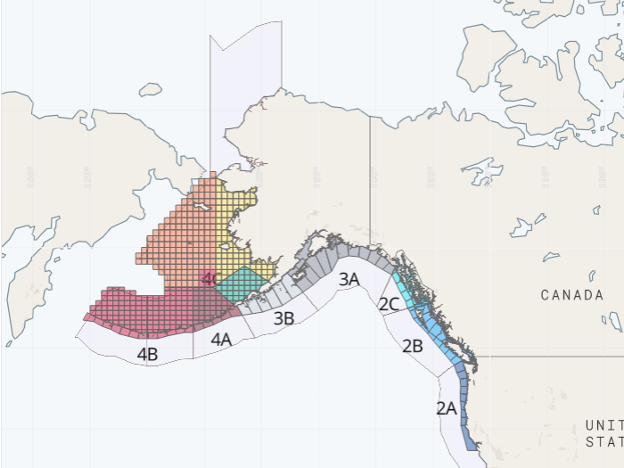

Figure 1: IPHC Statistical Areas. Source: https://www.iphc.int/data/geospatial-data/

Due to its economic importance to the region, concerns are rising about the sustainability of the stock and how management agencies can mitigate the impact of climate change on this species. In the past decade, the stock has been in a slow decline from historical levels, for reasons that have not been fully identified by stock assessment scientists.

[figure not shown]

Commercial fishermen hauling in Pacific Halibut. Source: nationalfisherman.com

We propose a solution that aims to predict future catch and landings of Pacific Halibut using a long-term dataset of environmental variables collected by the IPHC from these Regulatory Areas and applying similarity-based learning techniques. By leveraging a weighted k-Nearest Neighbors (k-NN) model, the goal is to develop a predictive capacity for local communities to foresee changes in the fishery in response to environmental shifts (e.g., rising sea temperatures). Such a model could also provide an evidentiary basis for funding and permissions to install permanent, stationary at-sea monitoring systems throughout the fishing grounds. These monitoring systems would support short-term predictive capacity and real-time ground-truthing of the model, while also informing IPHC management efforts regarding which Regulatory Areas may require closer attention due to the impacts of climate change.

```r
knitr::opts_chunk$set(echo = TRUE)

# load necessary libraries
library(dplyr)
library(tidyr)
```

## Data Set Exploration

The IPHC provides a substantial long-term datasets from which to develop and train the model. This includes both catch and environmental data, which are comprehensive and publicly available in .csv format.

### Water Column Profiler Data

The IPHC conducts an annual stock assessment survey using a standardized grid implemented for decades (Figure 2). At each sampling station, a water column profiler is deployed to collect data on depth, temperature, salinity, dissolved oxygen, pH, and chlorophyll-a concentrations. The dataset is organized by year and station, with divisions by regulatory area, dating back consistently to 2009.

- Data Source: [IPHC Water Column Profiler Data] (https://www.iphc.int/data/water-column-profiler-data/)

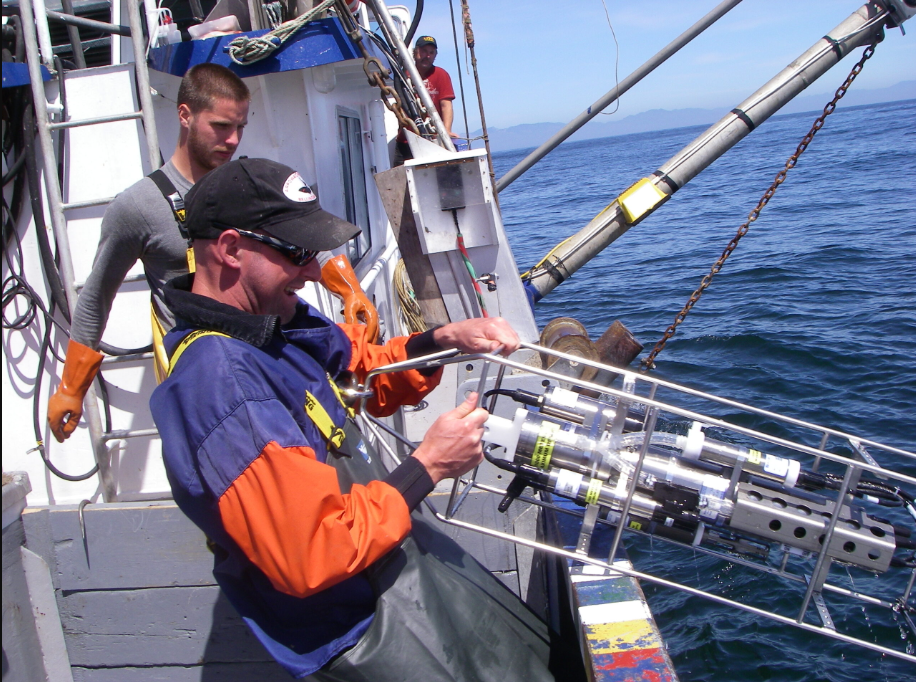

Water Column Profiler being deployed during the summer setline survey. Source: iphc.int

```r
# import raw water column profiler data, replace nulls with na

iphc2009 <- read.csv("iphc2009.csv", na.strings="null", header=TRUE)
iphc2010 <- read.csv("iphc2010.csv", na.strings="null", header=TRUE)
iphc2011 <- read.csv("iphc2011.csv", na.strings="null", header=TRUE)
iphc2012 <- read.csv("iphc2012.csv", na.strings="null", header=TRUE)
iphc2013 <- read.csv("iphc2013.csv", na.strings="null", header=TRUE)
iphc2014 <- read.csv("iphc2014.csv", na.strings="null", header=TRUE)
iphc2015 <- read.csv("iphc2015.csv", na.strings="null", header=TRUE)
iphc2016 <- read.csv("iphc2016.csv", na.strings="null", header=TRUE)
iphc2017 <- read.csv("iphc2017.csv", na.strings="null", header=TRUE)
iphc2018 <- read.csv("iphc2018.csv", na.strings="null", header=TRUE)
```

### Pacific Halibut Landings Data

The IPHC records annual landings for Pacific Halibut by year and Regulatory Area, with records spanning over 100 years.

- Data Source: [IPHC Time Series Datasets](https://www.iphc.int/data/time-series-datasets/

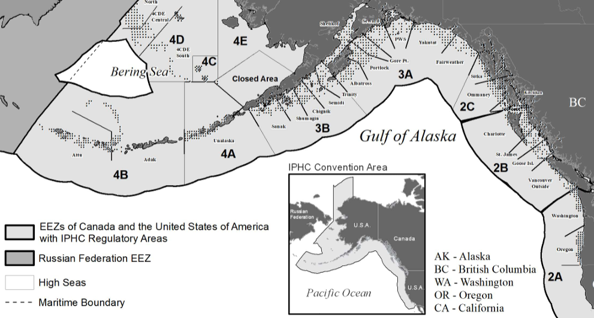

Figure 2: IPHC annual sample stations, each represented by a single black dot. Source: https://www.iphc.int/research/fishery-independent-setline-survey-fiss/

```r
# import raw landings data, replace nulls with na

landings <- read.csv("iphc_annual_landings.csv", header=TRUE)
```

### Cleaning Up the Datasets

The first step is to bind all of the raw data .csvs into a single dataframe.

Number of observations: 1,674,765

Number of variables: 20

```r
# bind all .csvs into a single data frame

profiler_data <- rbind(iphc2009, iphc2010, iphc2011, iphc2012, iphc2013, iphc2014, iphc2015, iphc2016, iphc2017, iphc2018)

summary(profiler_data)
```

```
##      stlkey              year          stnno         vslcde
##  Min.   :20090001   Min.   :2009   Min.   : 600   Length:1674765
##  1st Qu.:20110635   1st Qu.:2011   1st Qu.:3019   Class :character
##  Median :20140145   Median :2014   Median :4186   Mode  :character
##  Mean   :20135774   Mean   :2014   Mean   :4199
##  3rd Qu.:20160801   3rd Qu.:2016   3rd Qu.:5256
##  Max.   :20181514   Max.   :2018   Max.   :9530
##
##      setno             lat             lon         creationdate
##  Min.   :  1.00   Min.   :37.85   Min.   :-180.0   Length:1674765
##  1st Qu.: 29.00   1st Qu.:52.52   1st Qu.:-157.8   Class :character
##  Median : 59.00   Median :55.51   Median :-147.5   Mode  :character
##  Mean   : 63.72   Mean   :54.92   Mean   :-134.3
##  3rd Qu.: 93.00   3rd Qu.:58.17   3rd Qu.:-131.1
##  Max.   :212.00   Max.   :61.51   Max.   : 180.0
##
##     pres_db           temp_c         oxygen_ml            pH
##  Min.   :  0.00   Min.   :-1.702   Min.   :-2.15    Min.   :-0.63
##  1st Qu.: 36.00   1st Qu.: 5.364   1st Qu.: 3.90    1st Qu.: 7.81
##  Median : 76.00   Median : 6.387   Median : 5.68    Median : 8.00
##  Mean   : 96.43   Mean   : 6.770   Mean   : 5.14    Mean   : 7.90
##  3rd Qu.:134.00   3rd Qu.: 7.852   3rd Qu.: 6.44    3rd Qu.: 8.15
##  Max.   :999.00   Max.   :26.150   Max.   :26.97    Max.   :33.13
##                   NA's   :2355     NA's   :150923   NA's   :170753
##   chlorophyll       salinity_PSU    oxygen_umol       oxygen_sat
##  Min.   :-100.54   Min.   :-5.95   Min.   : 12.0    Min.   :  3.8
##  1st Qu.:  -0.01   1st Qu.:32.10   1st Qu.:172.8    1st Qu.: 56.7
##  Median :   0.11   Median :32.56   Median :249.8    Median : 81.5
##  Mean   :   0.78   Mean   :32.60   Mean   :225.5    Mean   : 74.8
##  3rd Qu.:   0.69   3rd Qu.:33.21   3rd Qu.:282.2    3rd Qu.: 93.7
##  Max.   : 184.21   Max.   :40.90   Max.   :615.4    Max.   :303.0
##  NA's   :50420     NA's   :45321   NA's   :593006   NA's   :599841
##      sigmat        bottomdepth       RegArea          ProfileEdit
##  Min.   :  3.3    Min.   :   0.0   Length:1674765     Length:1674765
##  1st Qu.: 25.1    1st Qu.: 128.0   Class :character   Class :character
##  Median : 25.6    Median : 181.0   Mode  :character   Mode  :character
##  Mean   : 25.8    Mean   : 204.4
##  3rd Qu.: 26.3    3rd Qu.: 260.0
##  Max.   :316.6    Max.   :5364.0
##  NA's   :557759   NA's   :176792
```

Now that dataframe can be filtered and manipulated, only the variables necessary to train and test the model are retained.

Based on the summary information, some of the records are not realistic (e.g. a pH of higher than 14), so they are likely data errors. First, we narrow the data frame down to the variables that are necessary for the training data, and then filter those variables into reasonable ranges.

```r
# select only necessary columns, filter to only top 50m of water column, filter environmental variables to reasonable ranges

profiler_data <- profiler_data %>%
  select(year, stnno, pres_db, temp_c, oxygen_ml, pH, chlorophyll, salinity_PSU, RegArea) %>%
  filter(
    pres_db >=2,
    pH >= 0 & pH <= 14,
    chlorophyll >= 0
  )

summary(profiler_data)
```

```
##       year          stnno         pres_db           temp_c
##  Min.   :2009   Min.   : 600   Min.   :  2.00   Min.   :-1.702
##  1st Qu.:2011   1st Qu.:3073   1st Qu.: 27.00   1st Qu.: 5.397
##  Median :2014   Median :4262   Median : 55.00   Median : 6.687
##  Mean   :2014   Mean   :4379   Mean   : 75.55   Mean   : 7.000
##  3rd Qu.:2016   3rd Qu.:6006   3rd Qu.:100.00   3rd Qu.: 8.298
##  Max.   :2018   Max.   :9530   Max.   :557.00   Max.   :23.136
##                                                 NA's   :630
##    oxygen_ml           pH          chlorophyll        salinity_PSU
##  Min.   :-1.71   Min.   : 0.000   Min.   :  0.0000   Min.   : 0.10
##  1st Qu.: 4.88   1st Qu.: 7.873   1st Qu.:  0.0739   1st Qu.:31.98
##  Median : 6.07   Median : 8.038   Median :  0.3182   Median :32.36
##  Mean   : 5.59   Mean   : 7.981   Mean   :  1.0656   Mean   :32.42
##  3rd Qu.: 6.63   3rd Qu.: 8.187   3rd Qu.:  1.0843   3rd Qu.:32.99
##  Max.   :23.90   Max.   :13.667   Max.   :128.1754   Max.   :40.52
##  NA's   :75984                                       NA's   :31683
##    RegArea
##  Length:1040714
##  Class :character
##  Mode  :character
##
##
##
##
```

Now that the variable have been reduced to reasonable ranges, we look at the distribution of the data to try and identify where more cleanup is needed.

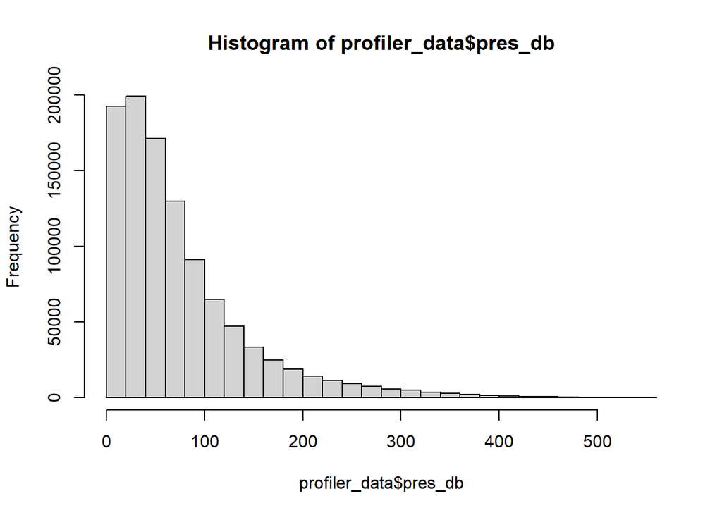

```r
hist(profiler_data$pres_db)
```

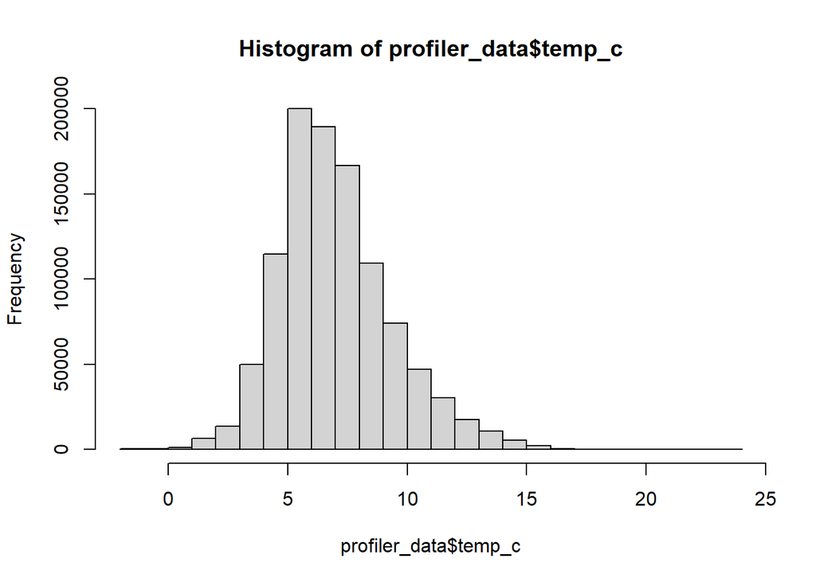

```r
hist(profiler_data$temp_c)
```

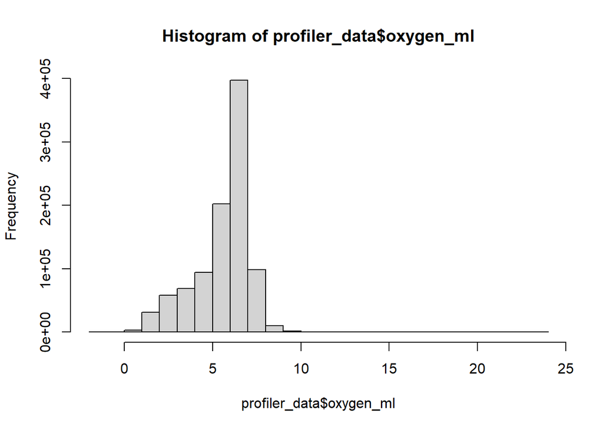

```r
hist(profiler_data$oxygen_ml)
```

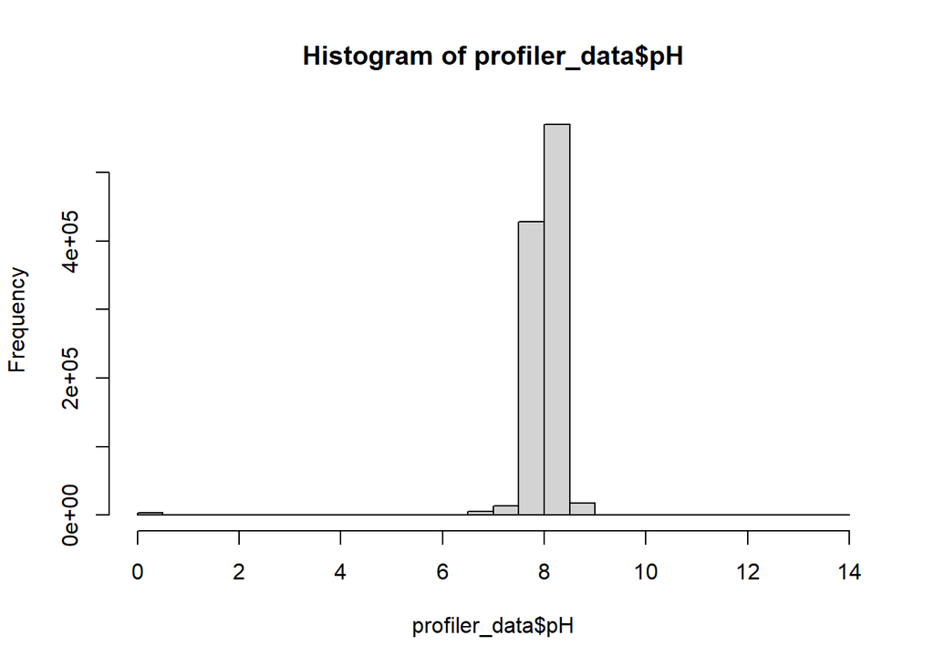

```r
hist(profiler_data$pH)
```

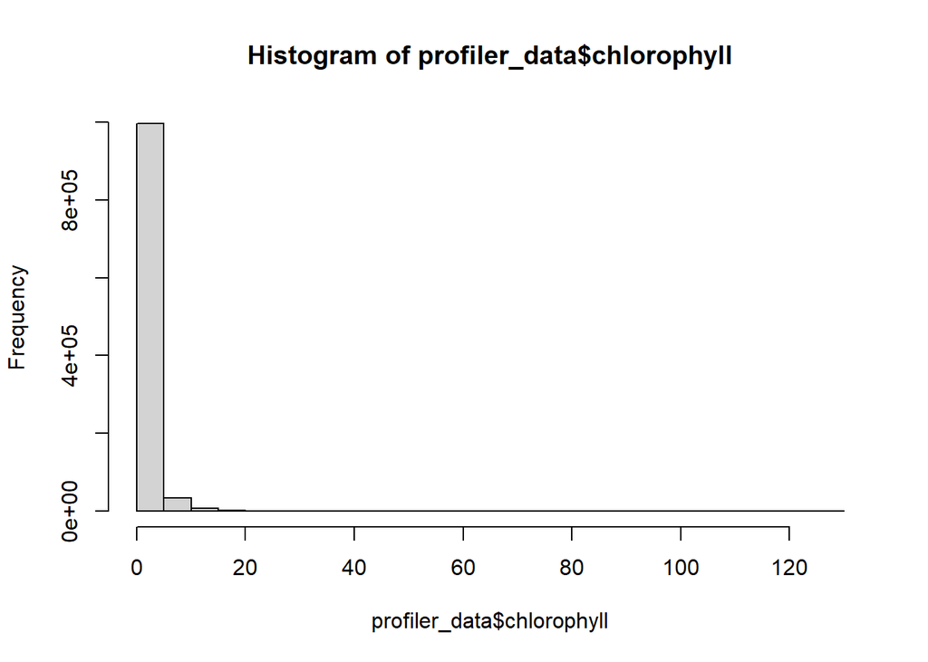

```r
hist(profiler_data$chlorophyll)
```

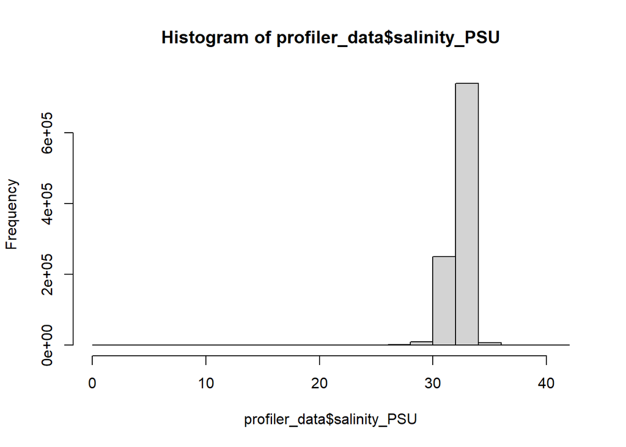

```r
hist(profiler_data$salinity_PSU)
```

Based on the histograms, it appears as though there are many outlier values in some of the variables.Because this data is collected by oceanographic equipment, it is likely that that outliers are due to instrument calibration issues. We will remove them using an IQR-based outlier removal method.

This is also important because we intend to use a kNN method, which is distance-based and therefore very sensitive to outliers.

```r
# Function to calculate IQR-based outlier bounds
remove_outliers <- function(x) {
  q1 <- quantile(x, 0.25, na.rm = TRUE)
  q3 <- quantile(x, 0.75, na.rm = TRUE)
  iqr <- q3 - q1
  lower <- q1 - 1.5 * iqr
  upper <- q3 + 1.5 * iqr
  x >= lower & x <= upper
}

# Remove outliers from multiple variables
profiler_data <- profiler_data %>%
  filter(
    remove_outliers(pres_db) &
    remove_outliers(temp_c) &
    remove_outliers(oxygen_ml) &
    remove_outliers(chlorophyll) &
    remove_outliers(salinity_PSU)
  )
```

When we look at the histograms again, the distribution of the data is much closer to the expected distributions.

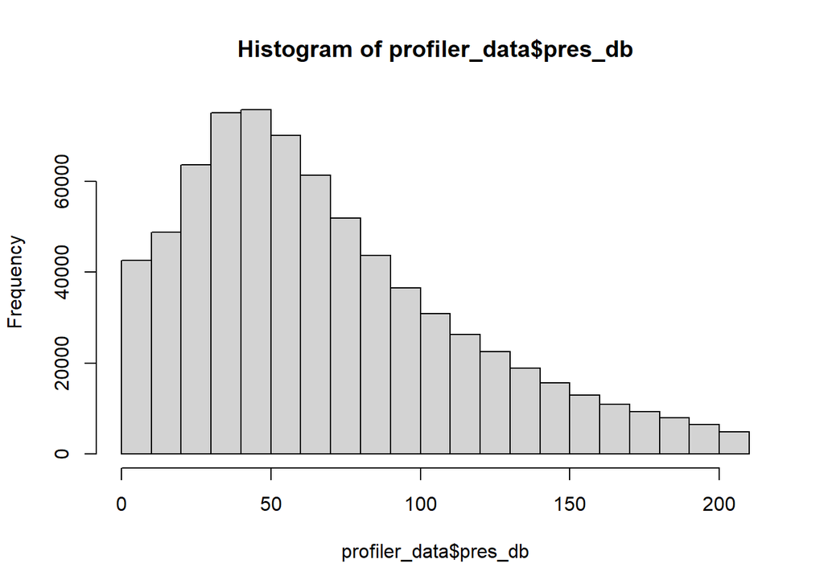

```r
hist(profiler_data$pres_db)
```

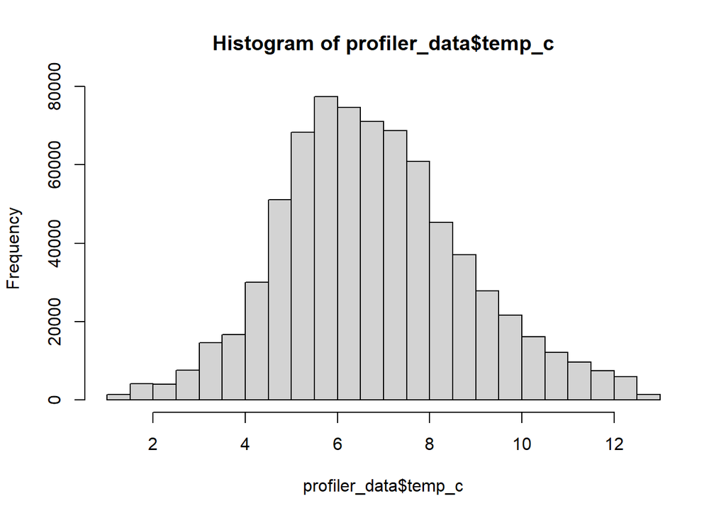

```r
hist(profiler_data$temp_c)
```

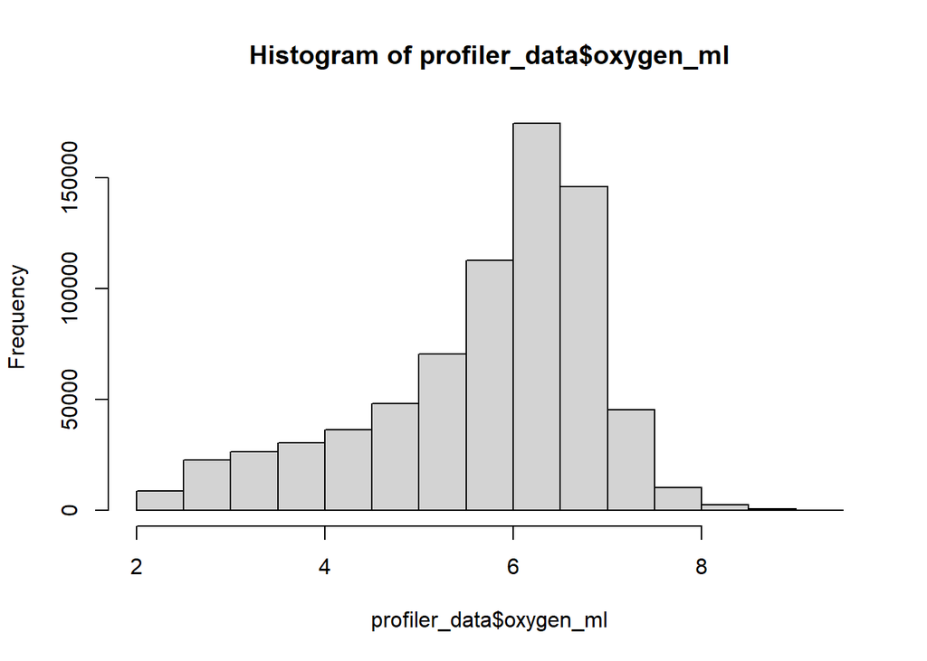

```r
hist(profiler_data$oxygen_ml)
```

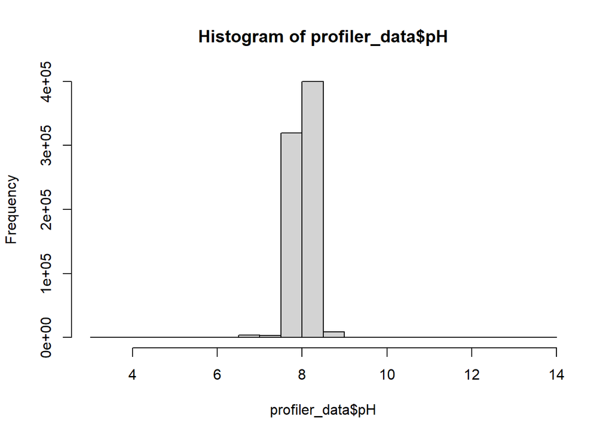

```r
hist(profiler_data$pH)
```

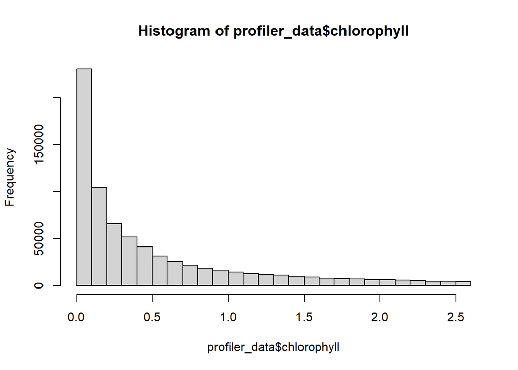

```r
hist(profiler_data$chlorophyll)
```

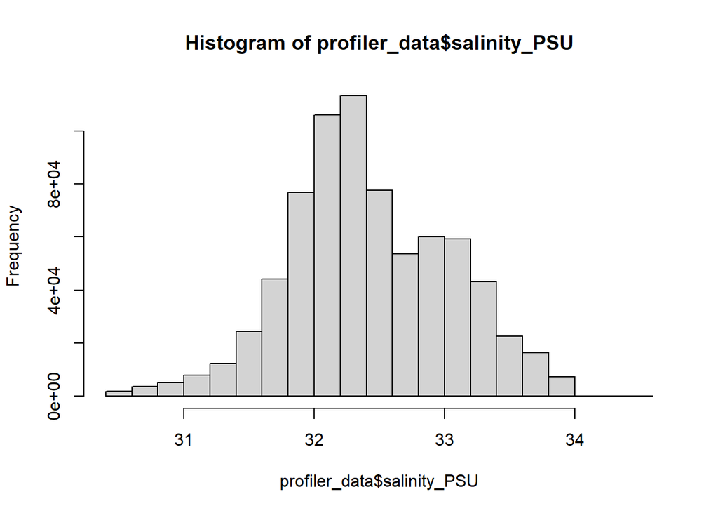

```r
hist(profiler_data$salinity_PSU)
```

Now the data is ready to average out by year, station, and variable to be used for training and testing the model.

Number of observations: 8987

```r
# average oceanographic variables by year and station

profiler_avg <- profiler_data %>%
  group_by(year, stnno, RegArea) %>%
  summarize(
    avg_temp = mean(temp_c, na.rm = TRUE),
    avg_oxy = mean(oxygen_ml, na.rm = TRUE),
    avg_chloro = mean(chlorophyll, na.rm = TRUE),
    avg_salin = mean(salinity_PSU, na.rm = TRUE),
    .groups = "drop"
  )
head(profiler_avg)
```

```
## # A tibble: 6 × 7
##    year stnno RegArea avg_temp avg_oxy avg_chloro avg_salin
##   <int> <int> <chr>      <dbl>   <dbl>      <dbl>     <dbl>
## 1  2009  1001 2A          9.20    4.54      0.257      33.2
## 2  2009  1002 2A          8.77    3.71      0.261      33.5
## 3  2009  1003 2A          9.46    4.35      0.422      33.3
## 4  2009  1004 2A          9.54    4.43      0.643      33.3
## 5  2009  1005 2A          8.98    3.92      0.298      33.5
## 6  2009  1006 2A          9.63    4.24      0.972      33.5
```

Next the dependent variable dataset needs some re-organizing before it can be combined with the environmental variable dataframe.

Variable names beginning with numbers are not compatible in RStudio, so the column names that came with the original data need to be temporarily adjusted to have the letter first, and the Areas in the water column profiler data need to be temporarily set to match.

```r
# rename landings columns

landings <- landings %>%
  rename(
    A2 = X2A,
    B2 = X2B,
    C2 = X2C,
    A3 = X3A,
    B3 = X3B,
    A4 = X4A,
    B4 = X4B
  )

# re-categorize RegArea value to match columns in landings data to prep for join

profiler_avg <- profiler_avg %>%
  mutate(RegArea = case_when(
    RegArea == "2A" ~ "A2",
    RegArea == "2B" ~ "B2",
    RegArea == "2C" ~ "C2",
    RegArea == "3A" ~ "A3",
    RegArea == "3B" ~ "B3",
    RegArea == "4A" ~ "A4",
    RegArea == "4B" ~ "B4",
    TRUE ~ RegArea  # Keeps other values unchanged
  )
)
head(profiler_avg)
```

```
## # A tibble: 6 × 7
##    year stnno RegArea avg_temp avg_oxy avg_chloro avg_salin
##   <int> <int> <chr>      <dbl>   <dbl>      <dbl>     <dbl>
## 1  2009  1001 A2          9.20    4.54      0.257      33.2
## 2  2009  1002 A2          8.77    3.71      0.261      33.5
## 3  2009  1003 A2          9.46    4.35      0.422      33.3
## 4  2009  1004 A2          9.54    4.43      0.643      33.3
## 5  2009  1005 A2          8.98    3.92      0.298      33.5
## 6  2009  1006 A2          9.63    4.24      0.972      33.5
```

Now we can combine the data frames.

Number of observations: 8987

```r
# reshape landings data to long format and join data frames
landings_pivot <- landings %>%
  pivot_longer(cols = -Year, names_to = "RegArea", values_to = "annual_landings")

iphc_fulldataset <- profiler_avg %>%
  left_join(landings_pivot, by = c("year" = "Year", "RegArea"))

head(iphc_fulldataset)
```

```
## # A tibble: 6 × 8
##    year stnno RegArea avg_temp avg_oxy avg_chloro avg_salin annual_landings
##   <int> <int> <chr>      <dbl>   <dbl>      <dbl>     <dbl>           <int>
## 1  2009  1001 A2          9.20    4.54      0.257      33.2             222
## 2  2009  1002 A2          8.77    3.71      0.261      33.5             222
## 3  2009  1003 A2          9.46    4.35      0.422      33.3             222
## 4  2009  1004 A2          9.54    4.43      0.643      33.3             222
## 5  2009  1005 A2          8.98    3.92      0.298      33.5             222
## 6  2009  1006 A2          9.63    4.24      0.972      33.5             222
```

The designations of the Regulatory Areas can now be returned back to normal. Only observations with specific regulatory areas specifed are retained.

Number of observations: 8454

```r
# return RegArea designations back to original coding

iphc_fulldataset <- iphc_fulldataset %>%
  mutate(RegArea = case_when(
    RegArea == "A2" ~ "2A",
    RegArea == "B2" ~ "2B",
    RegArea == "C2" ~ "2C",
    RegArea == "A3" ~ "3A",
    RegArea == "B3" ~ "3B",
    RegArea == "A4" ~ "4A",
    RegArea == "B4" ~ "4B"
  ))

iphc_fulldataset_full_depth <- iphc_fulldataset %>%
    filter(RegArea %in% c("2A", "2B", "2C", "3A", "3B", "4A", "4B"))

head(iphc_fulldataset_full_depth)
```

```
## # A tibble: 6 × 8
##    year stnno RegArea avg_temp avg_oxy avg_chloro avg_salin annual_landings
##   <int> <int> <chr>      <dbl>   <dbl>      <dbl>     <dbl>           <int>
## 1  2009  1001 2A          9.20    4.54      0.257      33.2             222
## 2  2009  1002 2A          8.77    3.71      0.261      33.5             222
## 3  2009  1003 2A          9.46    4.35      0.422      33.3             222
## 4  2009  1004 2A          9.54    4.43      0.643      33.3             222
## 5  2009  1005 2A          8.98    3.92      0.298      33.5             222
## 6  2009  1006 2A          9.63    4.24      0.972      33.5             222
```

Save file as a .csv so that it can be used to train and test the kNN model.

```r
# save as a .csv

write.csv(iphc_fulldataset_full_depth, directory, row.names=FALSE)
```